# Apresentação - TCC

#### Gabriel Franco

#### Universidade Federal de Viçosa

## Sumário

- Introdução ao DOTA2
- Primeira abordagem
- Estudos sobre a base de dados
- Referências

## Introdução ao DOTA2

- DOTA2 é um jogo de MOBA (*Multiplayer online battle arena*) onde o jogador controla um personagem em uma batalha entre dois times cujo objetivo é derrotar a base principal inimiga
- Mapa de DOTA2:

[figure not shown]

```python
from IPython.display import Image

Image(filename='presentation_data/dota2map.jpg')
```

Fonte: https://rabotnikof.net/dota-2-map. Acesso em 03/2018

- Existem cinco jogadores em cada time, cada um controlando um *hero* com, no mínimo, quatro *skills* disponíveis
- Os *heroes* são classificados de acordo com seus atributos primários, que são: *intelligence*, *strength* and *agility*
- Existem três *lanes*: *bot*, *top* e *mid*, além da *jungle*, onde o jogador pode *farmar*
- Cada jogador tem uma função específica (*carry*, *mid laner*, *support* e etc)
- Você adquire *gold* e *xp* no jogo matando *heroes* e *creeps* inimigos, ou matando *creeps* da *jungle*
- Com o *gold* adquirido no jogo, os jogadores podem comprar *items* que melhoram seus *stats* no jogo
- Com a *xp* adquirida, você sobe de *level*, podendo melhorar uma de suas *skills*. O *level* máximo no DOTA2 é o 25.

## Primeira abordagem

- A primeira abordagem que pensamos no trabalho foi a de usar redes complexas para tentar prever o comportamento de jogadores e/ou times no DOTA2. Era basicamente a mesma abordagem do trabalho do [Pedro de Melo](http://dcc.ufmg.br/dcc/?q=en/node/236), professor do [DCC-UFMG](http://dcc.ufmg.br/dcc/?q=pt-br). Neste trabalho, ele prevê o comportamento de times da NBA utilizando redes complexas.
- Essa primeira abordagem foi descartada depois de um tempo. O principal motivo é a falta de estudos e conhecimento prévio a cerca do problema, que não permite confiança nos modelos de análise de eficiência, como é utilizado no contexto do basquetebol pelo Pedro.

## Estudos sobre a base de dados

- Como não tinhamos conhecimento prévio a cerca do problema, resolvemos fazer um estudo de conhecimento da base de dados. Fizemos alguns estudos rápidos sobre a base e decidimos fazer alguns experimentos de clusterização
- A base de dados contém cerca de vinte mil jogadores. Para fazer os estudos, desconsideramos todos os jogadores com menos de cinco partidas.
- Cada jogador possui os seguintes atributos:

| Nome do atributo | Nomenclatura utilizada nos experimentos |
| --- | --- |
| kills | kills |
| deaths | deaths |
| assists | assists |
| denies | denies |
| hero damage | hd |
| hero healing | hh |
| last hits | lh |
| gold per minute | gpm |
| xp per minute | xpm |

- Todos os experimentos foram feitos com os dados normalizados por partida e utilizando normalização *min-max*
- Clusterizamos utilizando o *k-means* com o $k = [3, 4, 5]$ e $random\_state = 0$
- Esses foram todos os experimentos que nós fizemos:

| Nome do experimento | Atributos utilizados |
| --- | --- |
| all | "kills", "deaths", "assists", "denies", "lh" |
| kda | "kills", "deaths", "assists" |
| kdlh | "kills", "denies", "lh" |
| everyone | "kills", "deaths", "assists", "denies", "gpm", "hd", "hh", "lh", "xpm" |
| 5best | "kills", "gpm", "hd", "lh", "xpm" |
| 2best | "kills", "hd" |
| best | "hd" |
| wtf | "kills", "gpm", "lh", "xpm" |
| wohd | "kills","deaths", "assists", "denies", "gpm", "hh", "lh", "xpm" |

| Nome do experimento | Atributos utilizados |
| --- | --- |
| kills | "kills" |
| deaths | "deaths" |
| assists | "assists" |
| denies | "denies" |
| gpm | "gpm" |
| hh | "hh" |
| hd | "hd" |
| lh | "lh" |
| xpm | "xpm" |

#### Plot da inércia das classificações

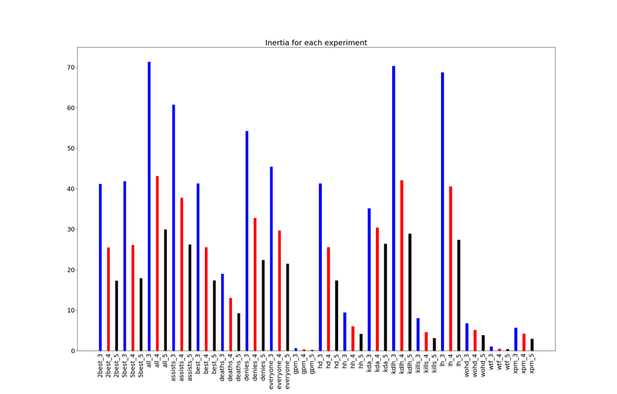

```python
Image(filename='data/inertia_new.png')
```

- Notamos que experimentos com inércia muito baixa, vide gpm e wtf, dão resultados ruins

#### Plot dos clusters com o experimento "gpm" rodando o k-means para $k = [3,4,5]$

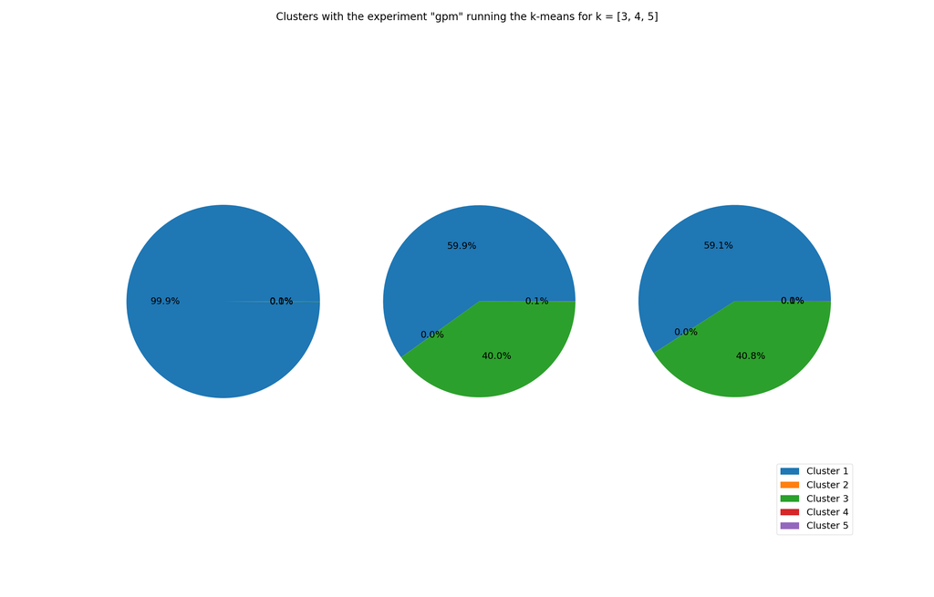

```python
Image(filename='data/gpm_pie.png')
```

#### Plot dos clusters com o experimento "wtf" rodando o k-means para $k = [3,4,5]$

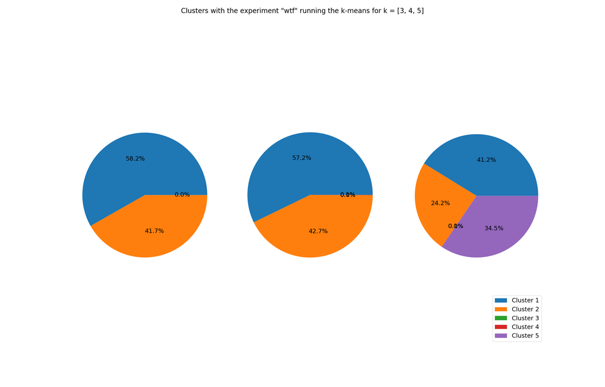

```python
Image(filename='data/wtf_pie.png')
```

- Notamos também que o atributo *hero_damage* é o que mais influencia na clusterização

#### Plot dos clusters com o experimento "everyone" rodando o k-means para $k = [3,4,5]$

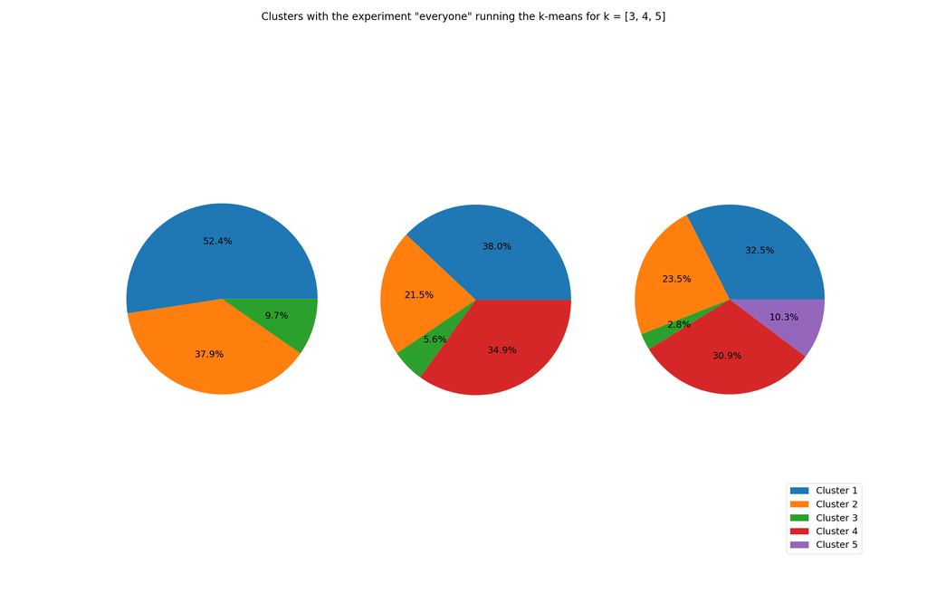

```python
Image(filename='data/everyone_pie.png')
```

#### Plot do atributo hd com $k = 5$, considerando o experimento everyone

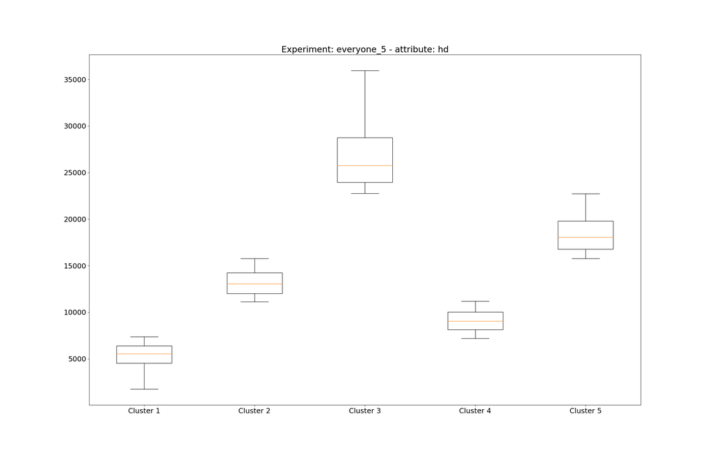

```python
Image(filename='data/everyone_5_hd.png')
```

#### Plot dos clusters com o experimento "hd" rodando o k-means para $k = [3,4,5]$

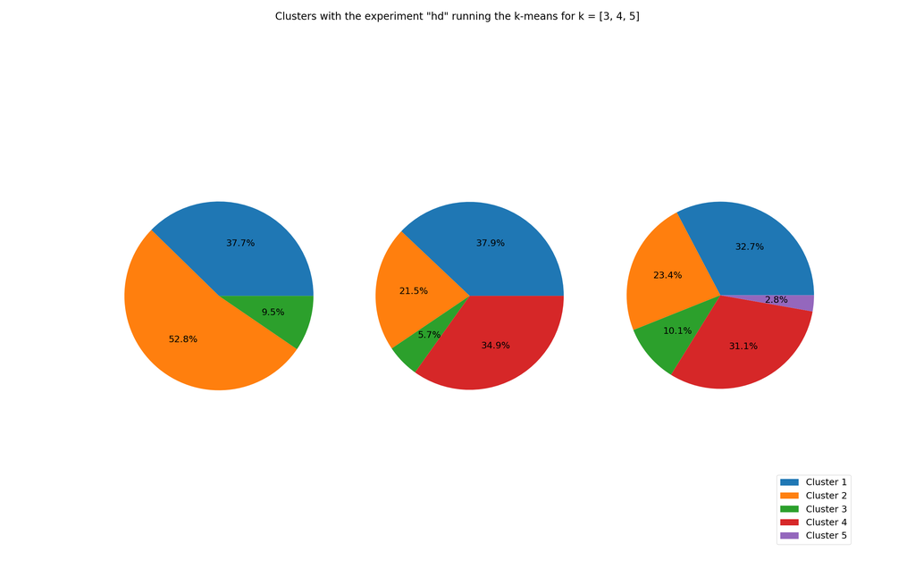

```python
Image(filename='data/hd_pie.png')
```

- Depois desses resultados, decidimos fazer uma clusterização utilizando a correlação de Pearson entre os atributos. Para cada atributo da base, clusterizamos ele com os quatros atributos que obtiveram o menor módulo da correlação com este atributo

#### Correlação dos atributos

```python
import numpy as np
import pandas as pd

def correlation_analysis(data, attributes):
    output_data = {}
    for i, attr in enumerate(attributes):
        output_data[attr] = []
        for d in data:
            output_data[attr].append(float(d[i]))

    df = pd.DataFrame(output_data)
    df = df.corr()

    return df
```

```python
def read_data():
    data = []
    fp = open('data/attributes.txt', 'r')
    for l in fp:
        parts = l.strip().split()
        for i, p in enumerate(parts):
            parts[i] = int(p)
        if parts[4] >= 5:
            data.append(list(np.array(parts[1:4] + parts[5:]) / parts[4]))
    fp.close()
    return data
```

```python
def highlight_attributes(att):
    att = att.apply(lambda x: abs(x))
    sorted_att = att.sort_values(ascending=True)
    sorted_list = list(sorted_att[:4])
    return ['background-color: grey' if value in sorted_list else '' for value in att]
```

```python
attributes_names = ["kills", "deaths", "assists", "denies", "gpm", "hd", "hh", "lh", "xpm"]

data = read_data()

df = correlation_analysis(data, attributes_names)

final_table = df.style.apply(highlight_attributes)

final_table
```

|  | assists | deaths | denies | gpm | hd | hh | kills | lh | xpm |
| --- | --- | --- | --- | --- | --- | --- | --- | --- | --- |
| assists | 1 | 0.155581 | -0.162655 | -0.0504124 | 0.188441 | 0.31795 | 0.0274202 | -0.0642791 | 0.0903118 |
| deaths | 0.155581 | 1 | -0.318721 | -0.147407 | -0.106294 | 0.0785398 | -0.200144 | -0.275298 | -0.265104 |
| denies | -0.162655 | -0.318721 | 1 | 0.262547 | 0.553665 | -0.271959 | 0.549112 | 0.747444 | 0.65065 |
| gpm | -0.0504124 | -0.147407 | 0.262547 | 1 | 0.338849 | -0.124404 | 0.425419 | 0.3182 | 0.58537 |
| hd | 0.188441 | -0.106294 | 0.553665 | 0.338849 | 1 | -0.163869 | 0.787169 | 0.75377 | 0.771611 |
| hh | 0.31795 | 0.0785398 | -0.271959 | -0.124404 | -0.163869 | 1 | -0.241149 | -0.287579 | -0.23052 |
| kills | 0.0274202 | -0.200144 | 0.549112 | 0.425419 | 0.787169 | -0.241149 | 1 | 0.655296 | 0.792073 |
| lh | -0.0642791 | -0.275298 | 0.747444 | 0.3182 | 0.75377 | -0.287579 | 0.655296 | 1 | 0.809 |
| xpm | 0.0903118 | -0.265104 | 0.65065 | 0.58537 | 0.771611 | -0.23052 | 0.792073 | 0.809 | 1 |

#### Experimentos feitos a partir dos dados da correlação

| Nome do experimento | Atributos |
| --- | --- |
| kills-corr | "kills", "assists", "deaths", "gpm", "hh" |
| deaths-corr | "deaths", "assists", "gpm", "hd", "hh" |
| assists-corr | "assists", "gpm", "kills", "lh", "xpm" |
| denies-corr | "denies", "assists", "deaths", "gpm", "hh" |
| gpm-corr | "gpm", "assists", "deaths", "denies", "hh" |
| hh-corr | "hh", "deaths", "gpm", "hd", "xpm" |
| hd-corr | "hd", "assists", "deaths", "gpm", "hh" |
| lh-corr | "lh", "assists", "deaths", "gpm", "hh" |
| xpm-corr | "xpm", "assists", "deaths" ,"gpm", "hh" |

#### Plot da inércia das classificações com a clusterização por correlação

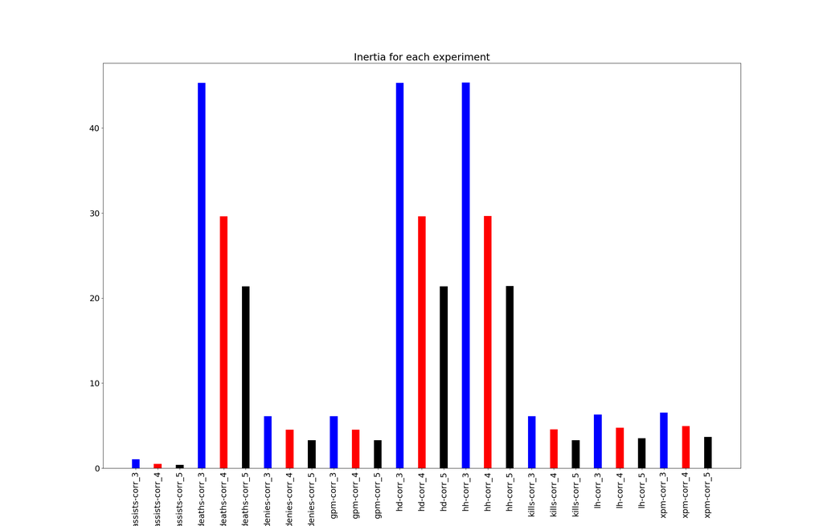

```python
Image(filename='data/inertia-corr.png')
```

#### Plot dos clusters com o experimento "assists-corr" rodando o k-means para $k = [3,4,5]$

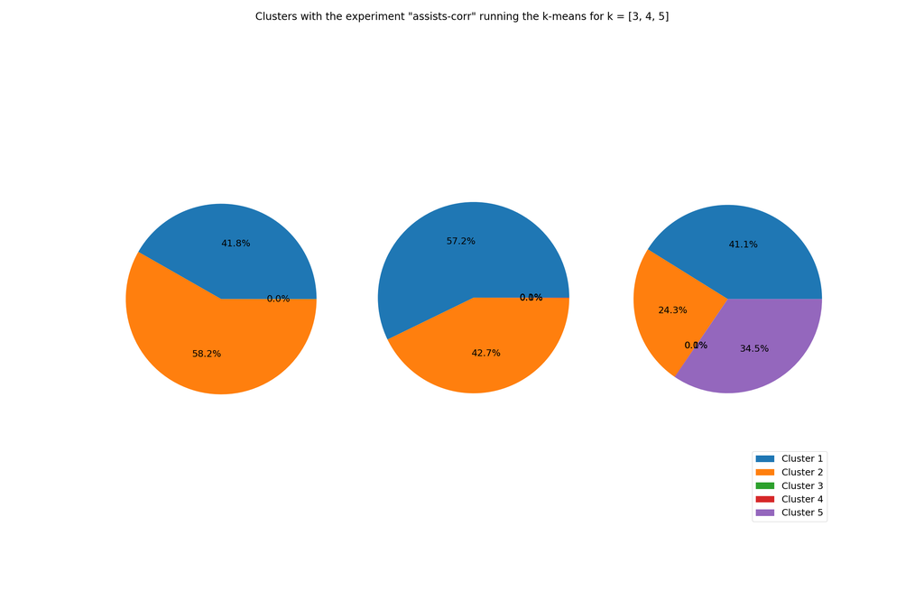

```python
Image(filename='data/assists-corr_pie.png')
```

## Referências

- https://dota2.gamepedia.com/Dota_2_Wiki. Acesso em 03/2018